# Modèle linéaire bayèsien

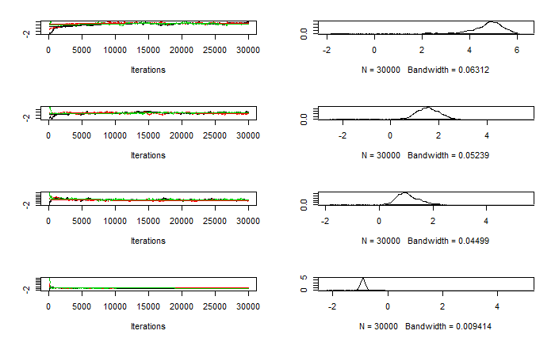

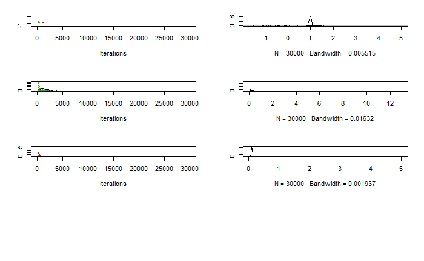

```r
 ## run chains in parallel:
 nchains = 3
 chainlist = list(MHchain$statesChain, MHchain$statesChain, MHchain$statesChain)
 for(k in 1:nchains){
   Startpar <-  list(theta = rep(-5 + k * 10/nchains, ncol(Phi_4)),
                     alpha = 0.01 + k * 5/nchains,
                     beta = 0.01 + k * 5/nchains)
   MHchain <- MH_lm(Phi = Phi_4, target = target_4, hyperpar = hyperpar,
                    proposalpar = list(sd_theta = 0.1, sd_alpha=0.05, sd_beta = 0.05),
                    startpar = Startpar,
                    Nsim = 30e+3)
   chainlist[[k]] <- mcmc(MHchain$statesChain)
 }

 chainlist <- mcmc.list(chainlist)

 plot(chainlist)
```

```r
 gg <- gelman.diag(chainlist)
 gg
```

```
Potential scale reduction factors:

     Point est. Upper C.I.
[1,]       1.20       1.59
[2,]       1.14       1.40
[3,]       1.26       1.74
[4,]       1.12       1.36
[5,]       1.19       1.56
[6,]       1.30       1.96
[7,]       1.03       1.09

Multivariate psrf

1.35
```

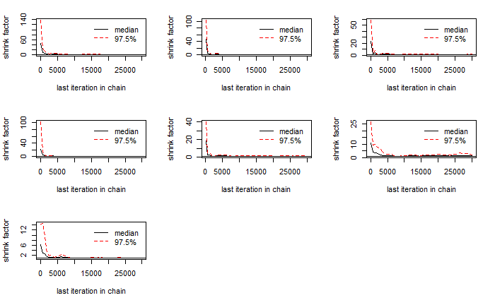

```r
 gp <- gelman.plot(chainlist)
```

```r
 hh <- heidel.diag(chainlist)
 hh
```

```
[[1]]

     Stationarity start     p-value
     test         iteration
var1 passed       6001      0.292
var2 passed       3001      0.197
var3 passed       3001      0.423
var4 passed       6001      0.150
var5 passed       3001      0.630
var6 passed          1      0.410
var7 passed       3001      0.942

     Halfwidth Mean   Halfwidth
     test
var1 passed     4.823 0.20324
var2 failed     1.641 0.19274
var3 failed     1.072 0.11364
var4 passed    -0.928 0.02358
var5 passed     0.990 0.01297
var6 failed     0.289 0.77074
var7 passed     0.110 0.00441

[[2]]

     Stationarity start     p-value
     test         iteration
var1 passed       3001      0.2494
var2 passed          1      0.7300
var3 passed       3001      0.4669
var4 passed          1      0.4721
var5 passed       3001      0.6247
var6 passed          1      0.0932
var7 passed          1      0.0663

     Halfwidth Mean   Halfwidth
     test
var1 passed     5.156 0.13859
var2 failed     1.482 0.21272
var3 passed     0.810 0.07137
var4 passed    -0.891 0.01782
```

[output cut: 10 more lines]

```
var3 passed        3001     0.1201
var4 passed       12001     0.1455
var5 passed           1     0.2582
var6 passed           1     0.6521
var7 passed        3001     0.8696

     Halfwidth Mean   Halfwidth
     test
var1 passed     4.731 0.24314
var2 passed     1.587 0.14198
var3 failed     1.151 0.13371
var4 passed    -0.926 0.02111
var5 passed     0.980 0.02243
var6 failed     0.317 0.30582
var7 passed     0.111 0.00478
```

On choisit ici le modèle ayant accepté le plus de tests, on définira les valeurs des paramètres retrouvés par ce modèle par la moyenne des derniers paramètres dans la liste (c’est à dire qu’on est sûr d’être au régime stationnaire).

```r
chosen_chain = chainlist[[3]]
theta_est1 = mean(tail(chosen_chain[,1], 1000))
theta_est2 = mean(tail(chosen_chain[,2], 1000))
theta_est3 = mean(tail(chosen_chain[,3], 1000))
theta_est4 = mean(tail(chosen_chain[,4], 1000))
theta_est5 = mean(tail(chosen_chain[,5], 1000))
theta_est = c(theta_est1, theta_est2, theta_est3, theta_est4, theta_est5)
alpha_est = mean(tail(chosen_chain[,6], 1000))
beta_est = mean(tail(chosen_chain[,5], 1000))
```

On définit la variance du paramètre $\theta$ par la différence entre la plus grande valeur et la plus petite valeur des valeurs considérées.

```r
variance_est = sapply(1:5, function(i){
  max(tail(chosen_chain[,i], 1000)) - min(tail(chosen_chain[,i], 1000))
})
```

On s’intéresse ici à comparer les valeurs de chaque composante de $\theta$ trouvées par la méthode variationnelle et par la méthode de Metropolis Hastings

```r
Iplus <- theta_est + 1.96*sqrt(variance_est)
Iminus <- theta_est - 1.96*sqrt(variance_est)
plot(L$varpar$m_n, pch=19,col='black',main = paste(" N = ", toString(N), sep=""), ylim =
       range(Iminus, Iplus, theta0))
points(theta_est, col='red')
```

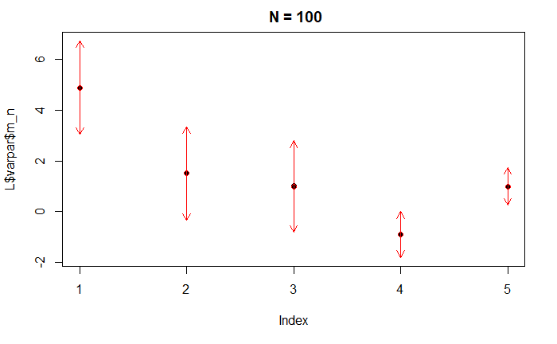

```r
arrows( x0 = 1:5, y0 = Iminus,
        y1 = Iplus ,code=3, length=0.1, col="red")
```

```r
# Les valeurs des paramètres theta par la méthode variationnelle et la méthode de Metropolis Hasting sont pratiquement les mêmes
```

### Algorithme de Gibbs

Dans cette partie, les valeurs des loi conditionnelles seraient prises comme on l’a fait dans la première partie pour toutes les $q_i$. La seule différence est qu’ici on ne considère pas l’espérence mais plutôt les valeurs réelles des paramètres.

```r
 ##' Gibbs sampler
 gibbs_lm <- function(Phi, target, hyperpar,
                      startpar = list(theta = rep(0,ncol(Phi)), alpha = 1, beta = 1),
                      Nsim = 10e+3 )
   ## ARGUMENTS:
   ## Phi: design matrix (feature map applied to data): a n*p matrix
   ## target: a  vector of size n: the observed values y.
   ## hyperpar: a list of hyperparameters containing entries a_0, lambda_0, b_0, tau_0:
   ##          hyper-prior gamma parameters respectively for alpha and beta
   ## startpar: the starting value for the chain: a list with entries theta, alpha, beta.
   ## Nsim: the desired length for the markov chain (number of MCMC interations)
   ##
   ## RETURNS: a list with entries :
   ## statesChain:  a matrix of dimension Nsim* (p+2): each row contains the current
   ##               state (concatenation of the vector theta, alpha, beta)
 ## lastpar: the latest state: a list with entries (theta, alpha, beta)
 ##
 {
   n <- nrow(Phi)
   p <- ncol(Phi)
   statesChain <- matrix(nrow=Nsim, ncol = p +2 )
   currentpar <- startpar
   an <-  hyperpar$a_0 + p/2
   bn <-  hyperpar$b_0 + n/2

   S_n <- function(alpha, beta){
     S_n_inv <- alpha * diag(p) + beta * t(Phi)%*%Phi
     return(solve(S_n_inv))
   }

   m_n <- function(alpha, beta){
     return(beta * S_n(alpha, beta) %*% t(Phi) %*% target)
   }

   lambda_n <- function(theta){
     return(hyperpar$lambda_0 + 0.5*t(theta)%*%theta)
   }

   tau_n <- function(theta){
     return(hyperpar$tau_0 + 0.5 * t(target - Phi%*%theta)%*%(target-Phi%*%theta))
   }

   simulate <-function(cpar){
    theta_sim = t(rmvnorm(1, mean = m_n(cpar$alpha, cpar$beta), sigma = S_n(cpar$alpha, cpar$beta)))
    alpha_sim = rgamma(1, shape = an, rate = lambda_n(theta_sim))
    theta_sim1 = t(rmvnorm(1, mean = m_n(alpha_sim, cpar$beta), sigma = S_n(alpha_sim, cpar$beta)))
    beta_sim = rgamma(1, shape = bn, rate = tau_n(theta_sim1))
    return(list(theta = theta_sim, alpha = alpha_sim, beta = beta_sim))
   }


   for (i in 1:Nsim){
     currentpar = simulate(currentpar)

     statesChain[i,] <- c(currentpar$theta, currentpar$alpha, currentpar$beta)

   }
   return(list( statesChain = statesChain, lastpar = currentpar ))
 }
```

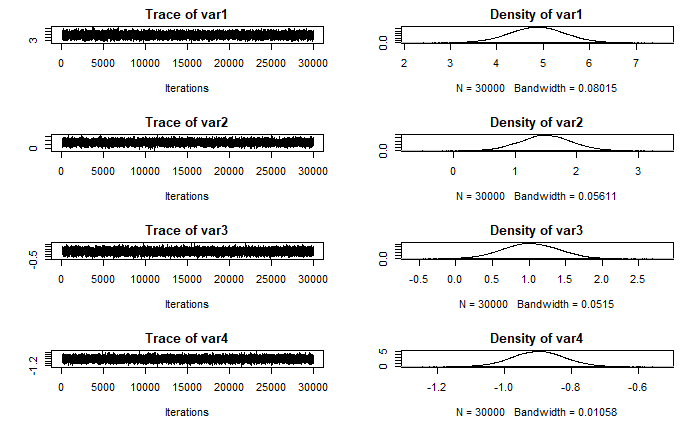

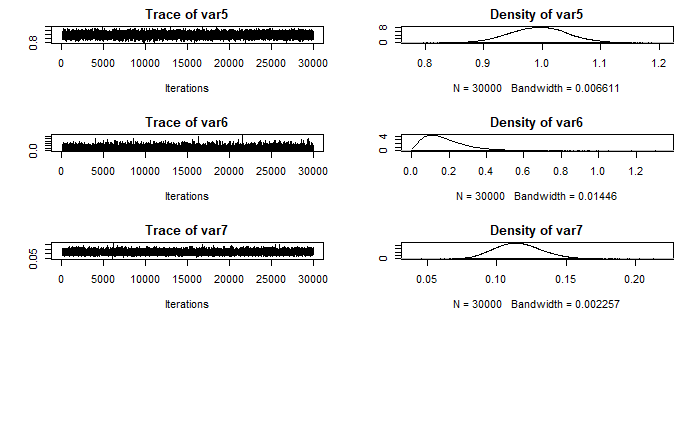

```r
 gibbschain <- gibbs_lm(Phi = Phi_4, target = target_4, hyperpar = hyperpar,
                  startpar = list(theta = rep(0, ncol(Phi_4)) , alpha = 1, beta = 1),
                  Nsim = 30e+3)

 plot(mcmc(gibbschain$statesChain))
```

```r
 hh <- heidel.diag(gibbschain$statesChain, pvalue = 0.05)
 hh
```

```
     Stationarity start     p-value
     test         iteration
[,1] passed       1         0.549
[,2] passed       1         0.187
[,3] passed       1         0.510
[,4] passed       1         0.277
[,5] passed       1         0.970
[,6] passed       1         0.439
[,7] passed       1         0.966

     Halfwidth Mean   Halfwidth
     test
[,1] passed     4.865 0.007253
[,2] passed     1.503 0.004827
[,3] passed     1.023 0.004468
[,4] passed    -0.898 0.000908
[,5] passed     0.994 0.000565
[,6] passed     0.182 0.001471
[,7] passed     0.116 0.000199
```